# Exercises_p134-137

ST

2018/5/24

Exercises_p134-137

```r
setwd("/Users/takamatsushiro/Desktop/DataAnalForLifeSci_R")
library(tidyverse)
```

# Exercises_p134-137

preparation

```r
data(ChickWeight)
head(ChickWeight)
```

```
## Grouped Data: weight ~ Time | Chick
##   weight Time Chick Diet
## 1     42    0     1    1
## 2     51    2     1    1
## 3     59    4     1    1
## 4     64    6     1    1
## 5     76    8     1    1
## 6     93   10     1    1
```

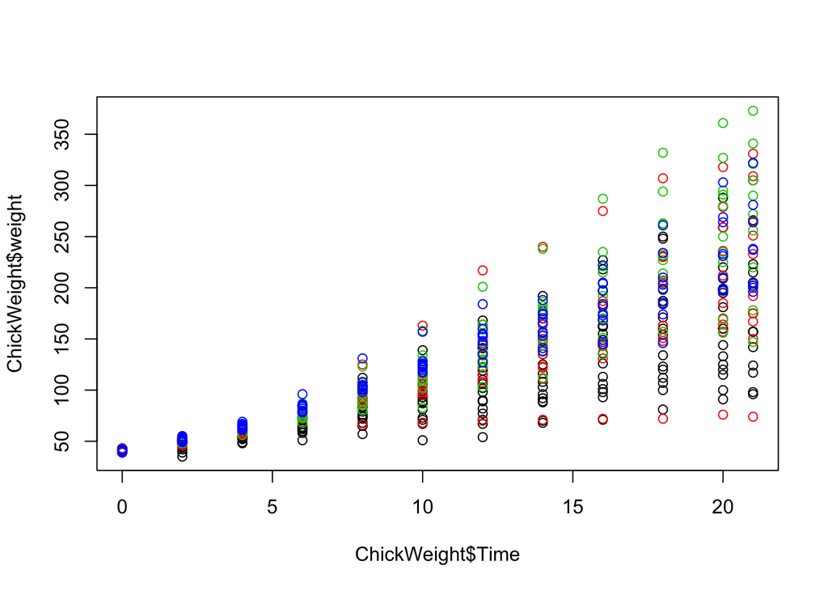

```r
plot( ChickWeight$Time, ChickWeight$weight, col=ChickWeight$Diet)
```

```r
chick <- reshape(ChickWeight, idvar=c("Chick","Diet"), timevar="Time",
                direction="wide")
head(chick)
```

```
##    Chick Diet weight.0 weight.2 weight.4 weight.6 weight.8 weight.10
## 1      1    1       42       51       59       64       76        93
## 13     2    1       40       49       58       72       84       103
## 25     3    1       43       39       55       67       84        99
## 37     4    1       42       49       56       67       74        87
## 49     5    1       41       42       48       60       79       106
## 61     6    1       41       49       59       74       97       124
##    weight.12 weight.14 weight.16 weight.18 weight.20 weight.21
## 1        106       125       149       171       199       205
## 13       122       138       162       187       209       215
## 25       115       138       163       187       198       202
## 37       102       108       136       154       160       157
## 49       141       164       197       199       220       223
## 61       141       148       155       160       160       157
```

```r
dim(chick)
```

```
## [1] 50 14
```

```r
chick = na.omit(chick)
```

1. Focus on the chick weights on day 4 (check the column names of ‘chick’ and note the numbers). How much does the average of chick weights at day 4 increase if we add an outlier measurement of 3000 grams? Specifically, what is the average weight of the day 4 chicks, including the outlier chick, divided by the average of the weight of the day 4 chicks without the outlier. Hint: use cto add a number to a vector.

```r
Day4_weight <- chick %>% dplyr::select(weight.4) %>% unlist()
Day0_weight <- chick %>% dplyr::select(weight.0) %>% unlist()
Day4_gain <- Day4_weight - Day0_weight
mean(Day4_gain) # the average increase of chick weights at day 4 without an outlier
```

```
## [1] 19.08889
```

```r
# add an outlier
add <- 3000
Day4_gain_add <- c(Day4_weight, add)
Day4_gain_add
```

```
##  weight.41  weight.42  weight.43  weight.44  weight.45  weight.46
##         59         58         55         56         48         59
##  weight.47  weight.48  weight.49 weight.410 weight.411 weight.412
##         57         59         52         63         56         53
## weight.413 weight.414 weight.415 weight.416 weight.417 weight.418
##         62         61         55         54         62         64
## weight.419 weight.420 weight.421 weight.422 weight.423 weight.424
##         61         58         62         57         58         58
## weight.425 weight.426 weight.427 weight.428 weight.429 weight.430
##         59         59         62         65         63         63
## weight.431 weight.432 weight.433 weight.434 weight.435 weight.436
##         64         61         56         61         61         66
## weight.437 weight.438 weight.439 weight.440 weight.441 weight.442
##         66         63         69         61         62         66
## weight.443 weight.444 weight.445
##         62         64         67       3000
```

```r
mean(Day4_gain_add) # the avearage increase of chick weight at day4 with an outlier
```

```
## [1] 124.0652
```

2. In exercise 1,we saw how sensitive the mean is to outliers.Now let’s see what happens when we use the median instead of the mean. Compute the same ratio, but now using median instead of mean. Specifically, what is the median weight of the day 4 chicks, including the outlier chick, divided by the median of the weight of the day 4 chicks without the outlier.

```r
median(Day4_gain)
```

```
## [1] 20
```

```r
median(Day4_gain_add)
```

```
## [1] 61
```

3. Now try the same thing with the sample standard deviation (the sd function in R). Add a chick with weight 3000 grams to the chick weights from day 4. How much does the standard deviation change? What’s the standard deviation with the outlier chick divided by the standard deviation without the outlier chick?

```r
sd(Day4_gain)
```

```
## [1] 4.491518
```

```r
sd(Day4_gain_add)
```

```
## [1] 433.4771
```

4.Compare the result above to the median absolute deviation in R, which is calculated with the mad function. Note that the mad is unaffected by the addition of a single outlier. The mad function in R includes the scaling factor 1.4826, such that mad and sd are very similar for a sample from a normal distribution. What’s the MAD with the outlier chick divided by the MAD without the outlier chick?

```r
mad(Day4_gain)
```

```
## [1] 4.4478
```

```r
mad(Day4_gain_add)
```

```
## [1] 4.4478
```

5.Our last question relates to how the Pearson correlation is affected by an outlier as compared to the Spearman correlation. The Pearson correlation between x and y is given in R by cor(x,y). The Spearman correlation is given by cor(x,y,method=“spearman”). Plot the weights of chicks from day 4 and day 21. We can see that there is some general trend, with the lower weight chicks on day 4 having low weight again on day 21, and likewise for the high weight chicks. Calculate the Pearson correlation of the weights of chicks from day 4 and day 21. Now calculate how much the Pearson correlation changes if we add a chick that weighs 3000 on day4 and 3000 on day 21. Again, divide the Pearson correlation with the outlier chick over the Pearson correlation computed without the outliers.

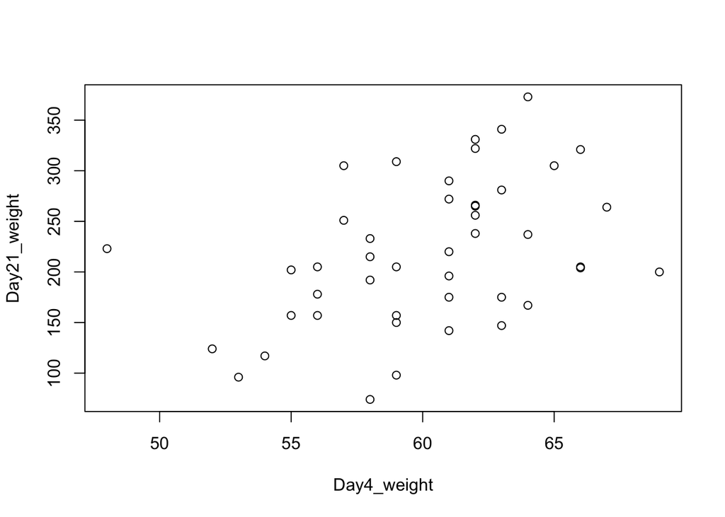

```r
Day21_weight <- unlist(chick$weight.21)
plot(Day4_weight,Day21_weight)
```

```r
cor(Day4_weight,Day21_weight) # Pearson
```

```
## [1] 0.4159499
```

```r
cor(Day4_weight,Day21_weight,method="spearman")  # Spearman
```

```
## [1] 0.4303941
```

```r
Day21_4_WG <- unlist(chick$weight.21) - unlist(chick$weight.4)

#add a chick that weighs 3000
Day4_weight_add <- c(Day4_weight, add)
Day21_weight_add <- c(Day21_weight, add)

cor(Day4_weight_add,Day21_weight_add)
```

```
## [1] 0.9861002
```

```r
cor(Day4_weight_add,Day21_weight_add,method="spearman")
```

```
## [1] 0.4669028
```

6.Save the weights of the chicks on day 4 from diet 1 as a vector x. Save the weights of the chicks on day 4 from diet 4 as a vector y. Perform a t-test comparing x and y (in R the function t.test(x,y) will perform the test). Then perform a Wilcoxon test of x and y (in R the function wilcox.test(x,y) will perform the test). A warning will appear that an exact p-value cannot be calculated with ties, so an approximation is used, which is fine for our purposes. Perform a t-test of x and y, after adding a single chick of weight 200 grams to x (the diet 1 chicks). What is the p-value from this test? The p-value of a test is available with the following code: t.test(x,y)$p.value

```r
Diet1 <- chick %>% dplyr::filter(Diet==1)
x <- as.vector(Diet1$weight.4)
y <- chick %>% dplyr::filter(Diet==4) %>% dplyr::select(weight.4) %>% unlist %>% as.vector()

t.test(x,y)
```

```
##
##  Welch Two Sample t-test
##
## data:  x and y
## t = -5.8393, df = 21.827, p-value = 7.32e-06
## alternative hypothesis: true difference in means is not equal to 0
## 95 percent confidence interval:
##  -10.513134  -5.000755
## sample estimates:
## mean of x mean of y
##  56.68750  64.44444
```

```r
wilcox.test(x,y)
```

```
## Warning in wilcox.test.default(x, y): cannot compute exact p-value with
## ties
```

```
##
##  Wilcoxon rank sum test with continuity correction
##
## data:  x and y
## W = 6, p-value = 0.0002012
## alternative hypothesis: true location shift is not equal to 0
```

```r
x_add <- c(x,200)

t.test(x_add,y)
```

```
##
##  Welch Two Sample t-test
##
## data:  x_add and y
## t = 0.078944, df = 16.358, p-value = 0.938
## alternative hypothesis: true difference in means is not equal to 0
## 95 percent confidence interval:
##  -17.37237  18.71878
## sample estimates:
## mean of x mean of y
##  65.11765  64.44444
```

```r
print(t.test(x,y)$p.value)
```

```
## [1] 7.320259e-06
```

```r
print(t.test(x_add,y)$p.value)
```

```
## [1] 0.9380347
```

7. Do the same for the Wilcoxon test. The Wilcoxon test is robust to the outlier.Inaddition,it has less assumptions that the t-test on the distribution of the underlying data.

```r
wilcox.test(x_add,y)
```

```
##
##  Wilcoxon rank sum test with continuity correction
##
## data:  x_add and y
## W = 15, p-value = 0.0009841
## alternative hypothesis: true location shift is not equal to 0
```

```r
print(wilcox.test(x,y)$p.value)
```

```
## [1] 0.0002011939
```

```r
print(wilcox.test(x_add,y)$p.value)
```

```
## [1] 0.0009840921
```

8. We will now investigate a possible downside to the Wilcoxon-Mann-Whitney test statistic. Using the following code to make three boxplots, showing the true Diet 1 vs 4 weights, and then two altered versions: one with an additional difference of 10 grams and one with an additional difference of 100 grams. Use the x and y as defined above, NOT the ones with the added outlier.

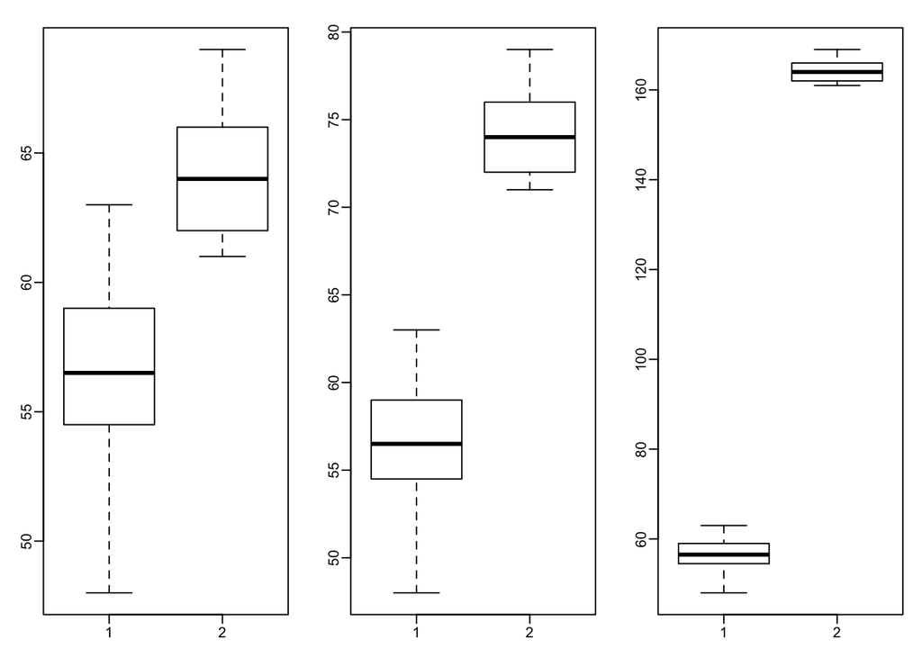

```r
library(rafalib)
mypar(1,3)
boxplot(x,y)
boxplot(x,y+10)
boxplot(x,y+100)
```

What is the difference in t-test statistic (obtained by t.test(x,y)$statistic) between adding 10 and adding 100 to all the values in the group ‘y’? Take the the t-test statistic with x and y+10 and subtract the t-test statistic with x and y+100. The value should be positive.

```r
t.test(x,y)$statistic
```

```
##         t
## -5.839339
```

```r
t.test(x,y+10)$statistic
```

```
##         t
## -13.36722
```

```r
t.test(x,y+100)$statistic
```

```
##         t
## -81.11819
```

9. Examine the Wilcoxon test statistic for x and y+10 and for x and y+100. Because the Wilcoxon works on ranks, once the two groups show complete separation, that is all points from group ‘y’ are above all points from group ‘x’, the statistic will not change, regardless of how large the difference grows. Likewise, the p-value has a minimum value, regardless of how far apart the groups are. This means that the Wilcoxon test can be considered less powerful than the t-test in certain contexts. In fact, for small sample sizes, the p-value can’t be very small, even when the difference is very large. What is the p-value if we compare c(1,2,3) to c(4,5,6) using a Wilcoxon test?

```r
wilcox.test(x,y)
```

```
##
##  Wilcoxon rank sum test with continuity correction
##
## data:  x and y
## W = 6, p-value = 0.0002012
## alternative hypothesis: true location shift is not equal to 0
```

```r
wilcox.test(x,y+10)
```

```
##
##  Wilcoxon rank sum test with continuity correction
##
## data:  x and y + 10
## W = 0, p-value = 5.032e-05
## alternative hypothesis: true location shift is not equal to 0
```

```r
wilcox.test(x,y+100)
```

```
##
##  Wilcoxon rank sum test with continuity correction
##
## data:  x and y + 100
## W = 0, p-value = 5.032e-05
## alternative hypothesis: true location shift is not equal to 0
```

```r
a <- c(1,2,3)
b <- c(4,5,6)
wilcox.test(a,b)
```

```
##
##  Wilcoxon rank sum test
##
## data:  a and b
## W = 0, p-value = 0.1
## alternative hypothesis: true location shift is not equal to 0
```

10. What is the p-value if we compare c(1,2,3) to c(400,500,600) usinga Wilcoxon test?

```r
wilcox.test(a,b*100)
```

```
##
##  Wilcoxon rank sum test
##
## data:  a and b * 100
## W = 0, p-value = 0.1
## alternative hypothesis: true location shift is not equal to 0
```